# Durana_Aritz_ADO_PEC2

Aritz Durana

9/6/2020

# ABSTRACT

Este informe trata sobre el análisis de datos de expresión RNA-seq de tres tipos de tejidos diferentes en un estudio de tiroides. Los datos se encuentran en el repositorio GTEx,[^1] que contiene datos de expresión génica en diferentes tejidos.

Todos los ficheros con los datos y el código utilizados para generar este informe se pueden encontrar en un repositorio de github.[^2]

# OBJETIVOS

El principal objetivo de este trabajo es estudiar el efecto de los diferentes tipos de tejidos en los datos de expresión génica. Para ello se partirá de unos datos de contaje previamente preprocesados.

Por otra parte, el objetivo de esta PEC2 es la realización de un análisis de datos de RNA-seq de una manera lo más fiel posible a la realidad. De este modo, es posible aplicar los conocimientos teóricos adquiridos a un caso práctico.

# MATERIALES Y MÉTODOS

## Software

Para la realización de este informe se ha utilizado [R](https://cran.r-project.org/index.html) (versión 4.0.1) y el interfaz [RStudio](https://www.rstudio.com/). Los paquetes específicos para el análisis de datos de RNA-seq se han obtenido del proyecto [Bioconductor](https://www.bioconductor.org/) (versión 3.11) que engloba los paquetes para análisis de datos ómicos más habituales.

## Datos

Los datos de partida para este estudio son los facilitados con el enunciado del ejercicio. Se trata de un archivo con los datos de conteos ya procesados `counts.csv` y de un archivo con los grupos y las covariables `targets.csv`.

## Workflow y métodos

El procedimiento general del análisis se puede resumir en los siguientes pasos. En cada paso se resume el tipo de tarea realizado y los métodos utilizados.

1. Preparación del entorno: Creación de directorios de trabajo.
2. Lectura de datos: Lectura de los ficheros `counts.csv` y `targets.csv` y modificación de datos Ensembl.
3. Modificación de los objetos `counts` y `targets`: Modificación para evitar problemas durante el análisis
4. Selección aleatoria de muestras: Selección de muestras para cada tipo de tejido.
5. Modificación del objeto `counts` según el muestreo: Selección de las columnas del objeto `counts` basada en la selección aleatoria de muestras.
6. Construcción de los objetos `DESeqDataSet` usando de datos sin normalizar: Creación de los objetos con `DESeq2` para desarrollar el análisis.
7. Filtraje de los datos: Filtraje para retirar las filas sin conteos.
8. Estabilización de la varianza: Transformación de los datos para estabilizar la varianza (vst y rlog).
9. Distancia entre las muestras: Gráfico para visualizar la distancia entre muestras.
10. Análisis de componentes principales (PCA): Visualización de PCA.
11. Análisis de expresión diferencial: Uso de la función `DESeq()`.
12. Contracción del cambio de log fold: Contracción de los resultados para posterior visualización.
13. Counts plot: Gráfico de contajes para visualizar los contajes de cada gen.
14. MA plot: Gráfico MA para observar la variabilidad en el contaje de cada gen sobre la media.
15. Gene clustering: Heatmap con el agrupamiento de los genes con más variabilidad.
16. Anotación: Se añaden los nombres de los genes a los resultados.
17. Resumen de resultados: Listado de los ficheros de resultados generados.

# RESULTADOS Y DISCUSIÓN

En esta sección se detallarán los resultados obtenidos en el análisis siguiendo el workflow descrito anteriormente. El código utilizado para realizar el análisis no se mostrará y solo se mostrarán los resultados más relevantes. Todo el código empleado para la realización del análisis se podrá encontrar en el apéndice que se encuentra al final de este informe además de en el repositorio de github mencionado anteriormente.<sup>2</sup> Hay que señalar que gran parte del análisis esta basado en diferentes análisis disponibles online y en los materiales de la asignatura.[^3]$^,$[^4]$^,$[^5]

## Preparación del entorno

Antes de descargar los datos y comenzar con el análisis es recomendable preparar el entorno de trabajo. Tras elegir el directorio de trabajo `workingDir`, se crearon los directorios para los datos `dataDir` y los resultados `resultsDir`.

## Lectura de datos

Los datos preprocesados se proporcionan en los materiales de la asignatura, en concreto los archivos `counts.csv` y `targets.csv`. Se leen y se guardan como objetos *R* utilizando la función `read.csv()`.

```r
> head(counts[,1:3],3)
```

|  | X | GTEX.111CU.0226.SM.5GZXC | GTEX.111FC.1026.SM.5GZX1 |
| --- | --- | --- | --- |
| 1 | ENSG00000223972.4 | 7 | 0 |
| 2 | ENSG00000227232.4 | 401 | 1064 |
| 3 | ENSG00000243485.2 | 4 | 0 |

```r
> head(targets, 3)
```

|  | Experiment | SRA_Sample | Sample_Name | Grupo_analisis | body_site | molecular_data_type | sex | Group | ShortName |
| --- | --- | --- | --- | --- | --- | --- | --- | --- | --- |
| 1 | SRX567480 | SRS626942 | GTEX-111CU-0226-SM-5GZXC | 1 | Thyroid | Allele-Specific Expression | male | NIT | 111CU_NIT |
| 2 | SRX615964 | SRS644174 | GTEX-111FC-1026-SM-5GZX1 | 1 | Thyroid | RNA Seq (NGS) | male | NIT | 111FC_NIT |
| 3 | SRX563960 | SRS625636 | GTEX-111VG-0526-SM-5N9BW | 3 | Thyroid | RNA Seq (NGS) | male | ELI | 111VG_ELI |

Se observó que había varios detalles en los datos que era recomendable modificar para evitar problemas durante el análisis.

## Modificación de los objetos `counts` y `targets`

La primera moficicación fue cambiar el nombre de la primera columna y quitar el final de los códigos *Ensemble* (el punto y el código de la versión) en el objeto `counts` para evitar problemas durante el análisis.

```r
> head(counts$Ensembl)
```

```
[1] "ENSG00000223972" "ENSG00000227232" "ENSG00000243485" "ENSG00000237613"
[5] "ENSG00000268020" "ENSG00000240361"
```

También se observó que en la columna `targets$Sample_Name`, los nombres de las muestras del experimento están separadas por guiones en lugar de por puntos como en `counts`. Se decidió cambiar todo a puntos.

```r
> targets$Sample_Name <- gsub("-", ".", x = as.character(targets$Sample_Name))
```

|  | Experiment | SRA_Sample | Sample_Name | Grupo_analisis | body_site | molecular_data_type | sex | Group | ShortName |
| --- | --- | --- | --- | --- | --- | --- | --- | --- | --- |
| 1 | SRX567480 | SRS626942 | GTEX.111CU.0226.SM.5GZXC | 1 | Thyroid | Allele-Specific Expression | male | NIT | 111CU_NIT |
| 2 | SRX615964 | SRS644174 | GTEX.111FC.1026.SM.5GZX1 | 1 | Thyroid | RNA Seq (NGS) | male | NIT | 111FC_NIT |
| 3 | SRX563960 | SRS625636 | GTEX.111VG.0526.SM.5N9BW | 3 | Thyroid | RNA Seq (NGS) | male | ELI | 111VG_ELI |

## Selección aleatoria de muestras

Tras la modificación preliminar de los datos, se realizó un muestreo aleatorio para cada uno de los tres tipos de tejidos definidos en `targets$Group`. Se eligieron 10 muestras aleatorias para cada uno de los tipos de tejido (*not infiltrated tissues* (NIT), *small local infiltrates* (SFI) y *extensive lymphoid infiltrates* (ELI)) tras aplicar la función `set.seed()` para asegurar la reproducibilidad del muestreo aleatorio. Obviamente, si se eligieran aleatoriamente otras 30 muestras diferentes el resultado final del análisis podría variar.

```r
> set.seed(2020)
>
> targets_ELI_rndm <- targets_ELI[sample(nrow(targets_ELI), 10),]
> targets_SFI_rndm <- targets_SFI[sample(nrow(targets_SFI), 10),]
> targets_NIT_rndm <- targets_NIT[sample(nrow(targets_NIT), 10),]
>
> targets_ELI_rndm
```

|  | Experiment | SRA_Sample | Sample_Name | Grupo_analisis | body_site | molecular_data_type | sex | Group | ShortName |
| --- | --- | --- | --- | --- | --- | --- | --- | --- | --- |
| 251 | SRX615373 | SRS644099 | GTEX.YFC4.2626.SM.5P9FQ | 3 | Thyroid | Allele-Specific Expression | female | ELI | YFC4-_ELI |
| 290 | SRX568364 | SRS627095 | GTEX.ZYY3.1926.SM.5GZXS | 3 | Thyroid | Allele-Specific Expression | female | ELI | ZYY3-_ELI |
| 147 | SRX607358 | SRS639491 | GTEX.14AS3.0226.SM.5Q5B6 | 3 | Thyroid | RNA Seq (NGS) | female | ELI | 14AS3_ELI |
| 146 | SRX575932 | SRS629299 | GTEX.14ABY.0926.SM.5Q5DY | 3 | Thyroid | Allele-Specific Expression | male | ELI | 14ABY_ELI |
| 149 | SRX568916 | SRS627158 | GTEX.14BMU.0226.SM.5S2QA | 3 | Thyroid | Allele-Specific Expression | female | ELI | 14BMU_ELI |
| 3 | SRX563960 | SRS625636 | GTEX.111VG.0526.SM.5N9BW | 3 | Thyroid | RNA Seq (NGS) | male | ELI | 111VG_ELI |
| 167 | SRX199272 | SRS333099 | GTEX.PLZ4.1226.SM.2I5FE | 3 | Thyroid | RNA Seq (NGS) | female | ELI | PLZ4-_ELI |
| 100 | SRX582762 | SRS631169 | GTEX.13NZ9.1126.SM.5MR37 | 3 | Thyroid | RNA Seq (NGS) | male | ELI | 13NZ9_ELI |
| 29 | SRX628009 | SRS648152 | GTEX.11NV4.0626.SM.5N9BR | 3 | Thyroid | RNA Seq (NGS) | male | ELI | 11NV4_ELI |
| 186 | SRX204036 | SRS374975 | GTEX.R55G.0726.SM.2TC6J | 3 | Thyroid | RNA Seq (NGS) | female | ELI | R55G-_ELI |

```r
> targets_SFI_rndm
```

|  | Experiment | SRA_Sample | Sample_Name | Grupo_analisis | body_site | molecular_data_type | sex | Group | ShortName |
| --- | --- | --- | --- | --- | --- | --- | --- | --- | --- |
| 44 | SRX576955 | SRS629456 | GTEX.1211K.0726.SM.5FQUW | 2 | Thyroid | Allele-Specific Expression | female | SFI | 1211K_SFI |
| 69 | SRX572541 | SRS627900 | GTEX.131YS.0726.SM.5P9G9 | 2 | Thyroid | Allele-Specific Expression | female | SFI | 131YS_SFI |
| 185 | SRX203531 | SRS374739 | GTEX.R55E.0826.SM.2TC5M | 2 | Thyroid | Allele-Specific Expression | male | SFI | R55E-_SFI |
| 210 | SRX222167 | SRS389523 | GTEX.TKQ1.0126.SM.33HB3 | 2 | Thyroid | RNA Seq (NGS) | male | SFI | TKQ1-_SFI |
| 21 | SRX619524 | SRS644703 | GTEX.11EQ8.0826.SM.5N9FG | 2 | Thyroid | Allele-Specific Expression | male | SFI | 11EQ8_SFI |
| 14 | SRX578169 | SRS629611 | GTEX.11DXY.0426.SM.5H12R | 2 | Thyroid | RNA Seq (NGS) | male | SFI | 11DXY_SFI |
| 261 | SRX596158 | SRS636581 | GTEX.ZE7O.1126.SM.57WC8 | 2 | Thyroid | Allele-Specific Expression | female | SFI | ZE7O-_SFI |
| 22 | SRX558144 | SRS623916 | GTEX.11EQ9.0626.SM.5A5K1 | 2 | Thyroid | RNA Seq (NGS) | male | SFI | 11EQ9_SFI |
| 66 | SRX596173 | SRS636582 | GTEX.131XF.1826.SM.5EGKG | 2 | Thyroid | RNA Seq (NGS) | male | SFI | 131XF_SFI |
| 252 | SRX630577 | SRS648438 | GTEX.YFCO.0326.SM.4W1ZP | 2 | Thyroid | Allele-Specific Expression | male | SFI | YFCO-_SFI |

```r
> targets_NIT_rndm
```

|  | Experiment | SRA_Sample | Sample_Name | Grupo_analisis | body_site | molecular_data_type | sex | Group | ShortName |
| --- | --- | --- | --- | --- | --- | --- | --- | --- | --- |
| 103 | SRX632368 | SRS648646 | GTEX.13O21.2226.SM.5MR3L | 1 | Thyroid | Allele-Specific Expression | male | NIT | 13O21_NIT |
| 222 | SRX260017 | SRS408175 | GTEX.WYBS.1926.SM.3NM8N | 1 | Thyroid | Allele-Specific Expression | female | NIT | WYBS-_NIT |
| 221 | SRX260081 | SRS408203 | GTEX.WOFL.0726.SM.3MJG4 | 1 | Thyroid | RNA Seq (NGS) | male | NIT | WOFL-_NIT |
| 105 | SRX640104 | SRS650077 | GTEX.13O3P.0726.SM.5J2OM | 1 | Thyroid | Allele-Specific Expression | male | NIT | 13O3P_NIT |
| 8 | SRX634479 | SRS648886 | GTEX.117XS.0526.SM.5987Q | 1 | Thyroid | Allele-Specific Expression | male | NIT | 117XS_NIT |
| 266 | SRX640567 | SRS650126 | GTEX.ZLWG.0526.SM.4WWFB | 1 | Thyroid | Allele-Specific Expression | female | NIT | ZLWG-_NIT |
| 24 | SRX579411 | SRS629803 | GTEX.11GSO.0626.SM.5A5LW | 1 | Thyroid | RNA Seq (NGS) | male | NIT | 11GSO_NIT |
| 267 | SRX603800 | SRS638569 | GTEX.ZPCL.0126.SM.4WWC8 | 1 | Thyroid | Allele-Specific Expression | female | NIT | ZPCL-_NIT |
| 71 | SRX604905 | SRS639191 | GTEX.132NY.1026.SM.5P9IY | 1 | Thyroid | RNA Seq (NGS) | male | NIT | 132NY_NIT |
| 291 | SRX576863 | SRS629439 | GTEX.ZZ64.0126.SM.5GZXA | 1 | Thyroid | Allele-Specific Expression | male | NIT | ZZ64-_NIT |

Para realizar las comparaciones posteriores, se combinaron estas muestras aleatorias en tres objetos (`targets_ELI_vs_NIT`, `targets_ELI_vs_SFI` y `targets_NIT_vs_SFI`), uno por cada una de las comparaciones.

## Modificación del archivo `counts` según el muestreo

Se generó un objeto de tipo `counts` para cada una de las comparaciones. Para ello, primero se creó un objeto con las 20 muestras de cada objeto `targets` para cada comparación y la información de *Ensembl* que luego se definió como los nombres de cada fila. Por último se comprobó que los valores de la columna `Sample_Name` de los objetos `targets` coincidía con las columnas de los objetos `counts`. Los tres objetos generados se llaman `counts_ELI_vs_NIT`, `counts_ELI_vs_SFI` y `counts_NIT_vs_SFI`.

A continuación se muestran los encabezados de estos objetos.

```r
> head(counts_ELI_vs_NIT[,1:3], 3)
```

|  | GTEX.111VG.0526.SM.5N9BW | GTEX.117XS.0526.SM.5987Q | GTEX.11GSO.0626.SM.5A5LW |
| --- | --- | --- | --- |
| ENSG00000223972 | 1 | 3 | 0 |
| ENSG00000227232 | 474 | 511 | 544 |
| ENSG00000243485 | 1 | 1 | 0 |

```r
> head(counts_ELI_vs_SFI[,1:3], 3)
```

|  | GTEX.111VG.0526.SM.5N9BW | GTEX.11DXY.0426.SM.5H12R | GTEX.11EQ8.0826.SM.5N9FG |
| --- | --- | --- | --- |
| ENSG00000223972 | 1 | 0 | 1 |
| ENSG00000227232 | 474 | 663 | 802 |
| ENSG00000243485 | 1 | 0 | 1 |

```r
> head(counts_NIT_vs_SFI[,1:3], 3)
```

|  | GTEX.117XS.0526.SM.5987Q | GTEX.11DXY.0426.SM.5H12R | GTEX.11EQ8.0826.SM.5N9FG |
| --- | --- | --- | --- |
| ENSG00000223972 | 3 | 0 | 1 |
| ENSG00000227232 | 511 | 663 | 802 |
| ENSG00000243485 | 1 | 0 | 1 |

## Construcción de los objetos `DESeqDataSet` usando de datos sin normalizar

El siguiente paso en el análisis es la creación de los objetos `DESeqDataSet` que servirán de partida para llevar a cabo el análisis. Es posible crear estos objetos a partir de matrices de contajes como se describe en diferentes tutoriales.<sup>5</sup> Es interesante mencionar que en este tutorial los autores recomiendan el uso de datos de conteo sin normalizar dado que las propias funciones del paquete `DESeq2` desarrollado por Love (2014) realizan las modificaciones estadísticas necesarias.

Tras cargar la librería `DESeq2`, se crearon los tres objetos (`dds_ELI_vs_NIT`, `dds_ELI_vs_SFI` y `dds_NIT_vs_SFI`) usando la función `DESeqDataSetFromMatrix()`. Es importante mencionar que estos objetos tiene que tener definida una fórmula de diseño en la que se expresen la variables con las que se va a modelar. En nuestro caso, la variable a estudiar es `Group`.

```r
> dds_ELI_vs_NIT
```

```
class: DESeqDataSet
dim: 56202 20
metadata(1): version
assays(1): counts
rownames(56202): ENSG00000223972 ENSG00000227232 ... ENSG00000210195
  ENSG00000210196
rowData names(0):
colnames(20): GTEX.111VG.0526.SM.5N9BW GTEX.117XS.0526.SM.5987Q ...
  GTEX.ZYY3.1926.SM.5GZXS GTEX.ZZ64.0126.SM.5GZXA
colData names(9): Experiment SRA_Sample ... Group ShortName
```

```r
> dds_ELI_vs_SFI
```

```
class: DESeqDataSet
dim: 56202 20
metadata(1): version
assays(1): counts
rownames(56202): ENSG00000223972 ENSG00000227232 ... ENSG00000210195
  ENSG00000210196
rowData names(0):
colnames(20): GTEX.111VG.0526.SM.5N9BW GTEX.11DXY.0426.SM.5H12R ...
  GTEX.ZE7O.1126.SM.57WC8 GTEX.ZYY3.1926.SM.5GZXS
colData names(9): Experiment SRA_Sample ... Group ShortName
```

```r
> dds_NIT_vs_SFI
```

```
class: DESeqDataSet
dim: 56202 20
metadata(1): version
assays(1): counts
rownames(56202): ENSG00000223972 ENSG00000227232 ... ENSG00000210195
  ENSG00000210196
rowData names(0):
colnames(20): GTEX.117XS.0526.SM.5987Q GTEX.11DXY.0426.SM.5H12R ...
  GTEX.ZPCL.0126.SM.4WWC8 GTEX.ZZ64.0126.SM.5GZXA
colData names(9): Experiment SRA_Sample ... Group ShortName
```

## Filtraje de los datos

A continuación se realizó el filtraje para retirar las filas sin nigún conteo. De esta manera se agilizará el análisis y se obtendrán mejores resultados.

```r
> nrow(dds_ELI_vs_NIT)
```

```
[1] 56202
```

```r
> keep_ELI_vs_NIT <- rowSums(counts(dds_ELI_vs_NIT)) > 1
> dds_ELI_vs_NIT <- dds_ELI_vs_NIT[keep_ELI_vs_NIT,]
> nrow(dds_ELI_vs_NIT)
```

```
[1] 41471
```

```r
> nrow(dds_ELI_vs_SFI)
```

```
[1] 56202
```

```r
> keep_ELI_vs_SFI <- rowSums(counts(dds_ELI_vs_SFI)) > 1
> dds_ELI_vs_SFI <- dds_ELI_vs_SFI[keep_ELI_vs_SFI,]
> nrow(dds_ELI_vs_SFI)
```

```
[1] 41613
```

```r
> nrow(dds_NIT_vs_SFI)
```

```
[1] 56202
```

```r
> keep_NIT_vs_SFI <- rowSums(counts(dds_NIT_vs_SFI)) > 1
> dds_NIT_vs_SFI <- dds_NIT_vs_SFI[keep_NIT_vs_SFI,]
> nrow(dds_NIT_vs_SFI)
```

```
[1] 41129
```

Se observó que se filtraron aproximadamente un 25% de filas sin conteos por cada comparación.

## Estabilización de la varianza

Para la mayoría de los métodos estadísticos exploratorios es recomendable que los datos tengan el mismo rango de varianza para diferentes valores medios. Para conteos de RNA-seq la estimación de la varianza crece con la media de los valores por lo que es necesario realizar una transformación en aras de obtener una visualización correcta de los datos.

`DESeq2` ofrece dos transformaciones para estabilizar la varianza a lo largo de los valores de la media: *vst* para datos con distribución binomial negativa (Anders 2010) y *rlog* para la transformación del logaritmo regularizado (Love 2014).

Se hacen las transformaciones para las tres comparaciones con lo que se obtienen los objetos `vsd_ELI_vs_NIT`, `vsd_ELI_vs_SFI` y `vsd_NIT_vs_SFI` para el método *vst* y `rld_ELI_vs_NIT`, `rld_ELI_vs_SFI` y `rld_NIT_vs_SFI` para el método *rlog*. Se utilizarán estos objetos en lugar de los `dds` para la visualización de los datos.

## Distancia entre las muestras

Un primer análisis para la visualización de los datos es calcular la distancia euclidea entre las diferentes muestras. De este modo se puede evaluar si estas distancias concuerdan con el diseño experimental. Como en todo el análisis se crean tres nuevos objetos con las distancias entre muestras. Para una contribución similar de todos los genes se utilizan los datos *vst*.

Con estas distancias se puede generar un heatmap que permite analizar si el diseño del experimento ha sido correcto.

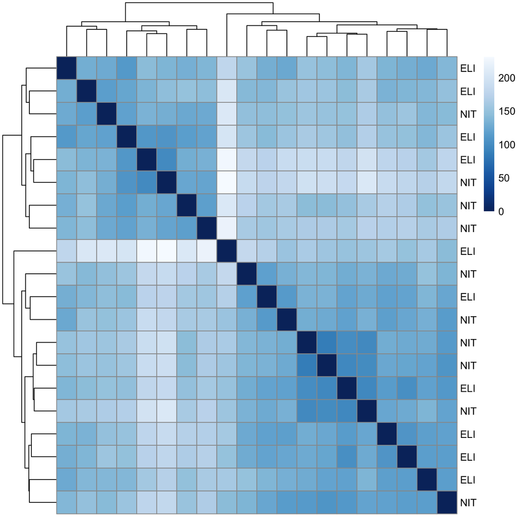

Distancias entre muestras para comparación ELI_vs_NIT

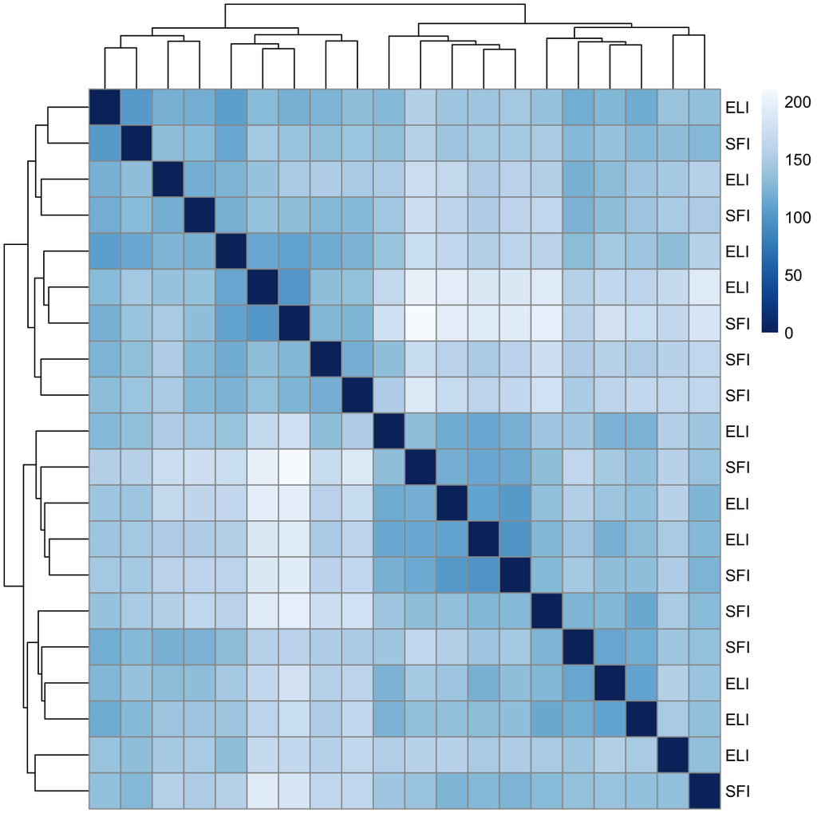

Distancias entre muestras para comparación ELI_vs_SFI

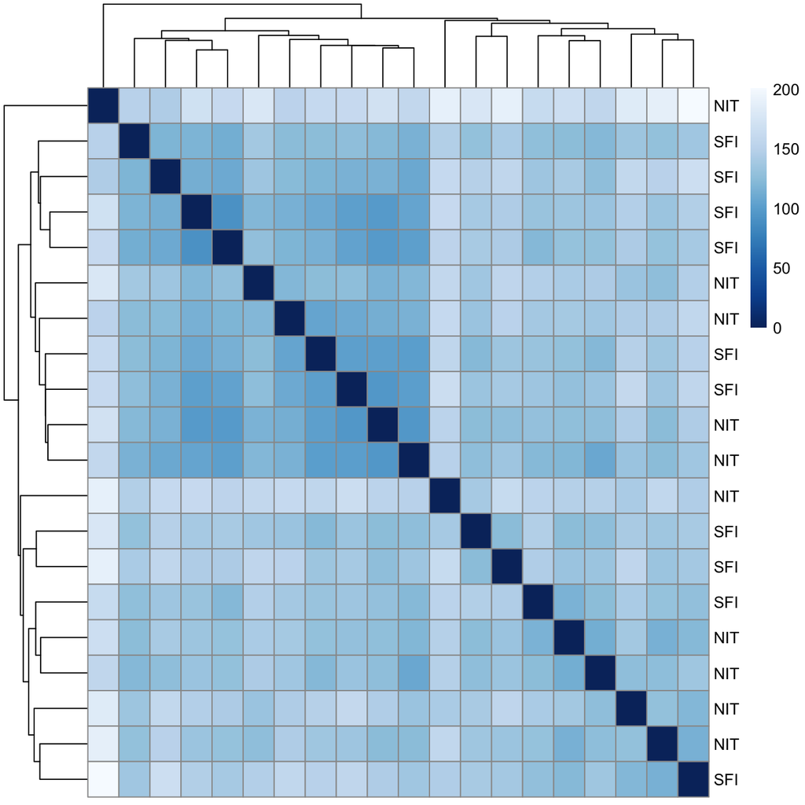

Distancias entre muestras para comparación NIT_vs_SFI

En niguno de los tres gráficos se observa una correlación clara entre las distancias de las muestras y el tipo de tejido. Esto puede deberse a un diseño experimental poco acertado o, más probablemente, a una alta variabilidad debido al reducido número de muestras del muestreo aleatorio.

## Análisis de componentes principales (PCA)

Una manera muy utilizada de visualizar los datos es mediante el análsis de componentes principales. Este método se basa en representar las muestras con respecto a las dos variables que más aportan a la variablidad de los datos. En el eje x se representa la componente que más aporta a la variabilidad total y en el eje y la segunda variable que más aporta. Se generan tres gráficos, uno por cada comparación usando la función `plotPCA()`.

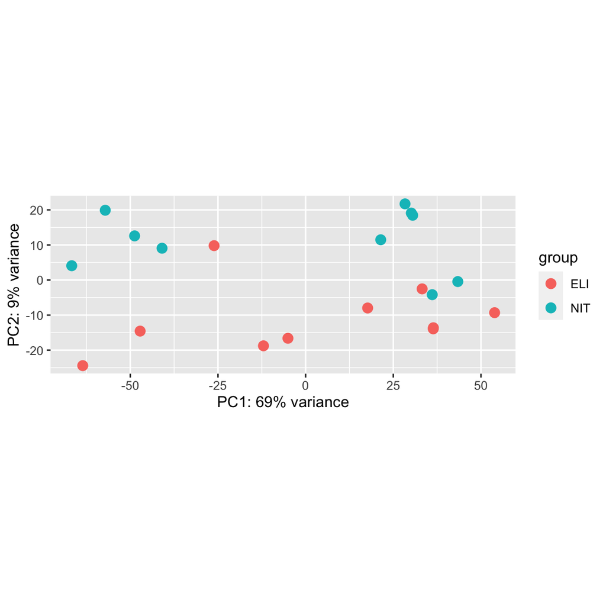

Plot PCA para comparación ELI_vs_NIT

En el caso de la comparación `ELI_vs_NIT` se observó que las muestras del grupo *ELI* se encuentras repartidas por todo el gráfico, lo que implica que no dependen de los dos componentes principales. En cuanto a las muestras del grupo *NIT* si que se encuentran agrupadas en valores absolutos elevados de variación en el componente principal lo que puede indicar que el tipo de tejido puede tener cierta relación con la variabilidad de las muestras.

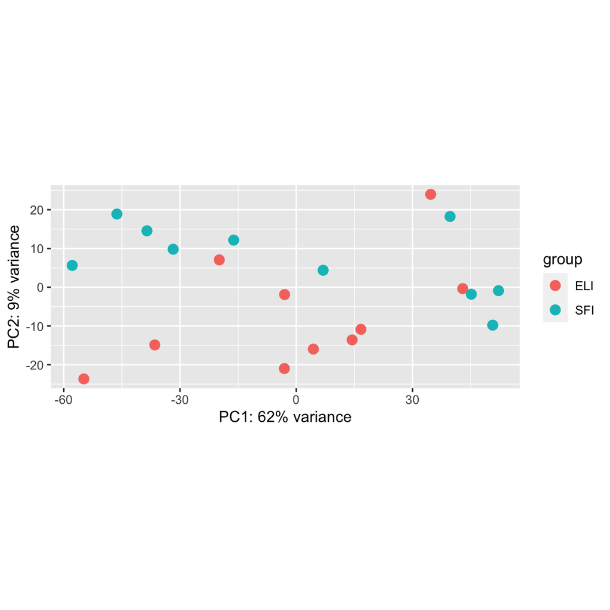

Plot PCA para comparación ELI_vs_SFI

En el caso de la comparación `ELI_vs_SFI` se observó que las muestras se encuentran bastante repartidas por todo el gráfico por lo que no se espera que el grupo sea una variable que defina la variabilidad de las muestras.

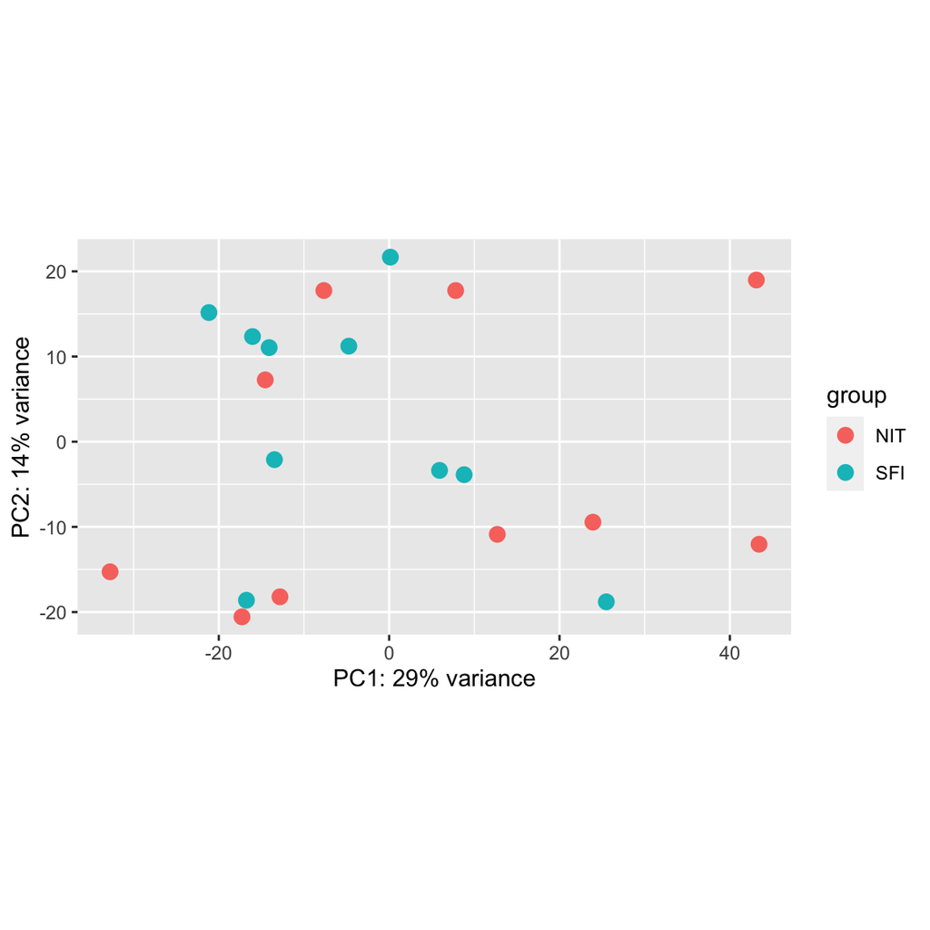

Plot PCA para comparación NIT_vs_SFI

Por último, en el caso de la comparación `NIT_vs_SFI` tampoco se observó un agrupamiento demasiado clara por grupos. Además la contribución a la variabilidad total del componente principal en esta comparación es mucho menor que en los otros casos (29% frente a 62% y 69%). Este resultado poco concluyente puede deberse al bajo número de muestras aleatorias utilizadas en el análisis.

## Análisis de expresión diferencial

En el caso del paquete `DESeq2`, todos los pasos del análisis de expresión diferencial estándar se encuentran resumidos dentro de la función `DESeq()`. Tras aplicar esta función a los objetos `DESeqDataSet` creados anteriormente se pueden obtener los resultados de este análisis mediante la función `results()` lo que permite continuar con el estudio. En este paso se generaron tres objetos de resultados (`res_ELI_vs_NIT`, `res_ELI_vs_SFI` y `res_NIT_vs_SFI`). Hay que mencionar que para realizar el análisis de expresión diferencial se utilizan los datos sin normalizar por lo que se utilizan los datos de tipo `dds`.

```r
> dds_ELI_vs_NIT
```

```
class: DESeqDataSet
dim: 41471 20
metadata(1): version
assays(6): counts mu ... replaceCounts replaceCooks
rownames(41471): ENSG00000223972 ENSG00000227232 ... ENSG00000210195
  ENSG00000210196
rowData names(23): baseMean baseVar ... maxCooks replace
colnames(20): GTEX.111VG.0526.SM.5N9BW GTEX.117XS.0526.SM.5987Q ...
  GTEX.ZYY3.1926.SM.5GZXS GTEX.ZZ64.0126.SM.5GZXA
colData names(11): Experiment SRA_Sample ... sizeFactor replaceable
```

```r
> head(res_ELI_vs_NIT, 5)
```

```
log2 fold change (MLE): Group NIT vs ELI
Wald test p-value: Group NIT vs ELI
DataFrame with 5 rows and 6 columns
                  baseMean log2FoldChange     lfcSE      stat    pvalue
                 <numeric>      <numeric> <numeric> <numeric> <numeric>
ENSG00000223972   2.784280       1.483200  0.668900  2.217371 0.0265977
ENSG00000227232 716.305631      -0.202647  0.199483 -1.015859 0.3096965
ENSG00000243485   1.123353       0.503209  0.809002  0.622013 0.5339335
ENSG00000237613   1.546790      -0.222971  1.045512 -0.213265 0.8311204
ENSG00000268020   0.686983       1.489907  1.171460  1.271838 0.2034307
                     padj
                <numeric>
ENSG00000223972        NA
ENSG00000227232  0.777587
ENSG00000243485        NA
ENSG00000237613        NA
ENSG00000268020        NA
```

```r
> dds_ELI_vs_SFI
```

```
class: DESeqDataSet
dim: 41613 20
metadata(1): version
assays(6): counts mu ... replaceCounts replaceCooks
rownames(41613): ENSG00000223972 ENSG00000227232 ... ENSG00000210195
  ENSG00000210196
rowData names(23): baseMean baseVar ... maxCooks replace
colnames(20): GTEX.111VG.0526.SM.5N9BW GTEX.11DXY.0426.SM.5H12R ...
  GTEX.ZE7O.1126.SM.57WC8 GTEX.ZYY3.1926.SM.5GZXS
colData names(11): Experiment SRA_Sample ... sizeFactor replaceable
```

```r
> head(res_ELI_vs_SFI,5)
```

```
log2 fold change (MLE): Group SFI vs ELI
Wald test p-value: Group SFI vs ELI
DataFrame with 5 rows and 6 columns
                  baseMean log2FoldChange     lfcSE       stat    pvalue
                 <numeric>      <numeric> <numeric>  <numeric> <numeric>
ENSG00000223972   2.984601      0.8361734  0.671842  1.2445974  0.213280
ENSG00000227232 747.622095     -0.0130042  0.219659 -0.0592018  0.952791
ENSG00000243485   1.229237     -0.1119309  0.733361 -0.1526273  0.878692
ENSG00000237613   1.152566      1.2161511  1.092448  1.1132345  0.265608
ENSG00000268020   0.706418      1.2184276  1.162879  1.0477684  0.294745
                     padj
                <numeric>
ENSG00000223972  0.999518
ENSG00000227232  0.999518
ENSG00000243485  0.999518
ENSG00000237613  0.999518
ENSG00000268020  0.999518
```

```r
> dds_NIT_vs_SFI
```

```
class: DESeqDataSet
dim: 41129 20
metadata(1): version
assays(6): counts mu ... replaceCounts replaceCooks
rownames(41129): ENSG00000223972 ENSG00000227232 ... ENSG00000210195
  ENSG00000210196
rowData names(23): baseMean baseVar ... maxCooks replace
colnames(20): GTEX.117XS.0526.SM.5987Q GTEX.11DXY.0426.SM.5H12R ...
  GTEX.ZPCL.0126.SM.4WWC8 GTEX.ZZ64.0126.SM.5GZXA
colData names(11): Experiment SRA_Sample ... sizeFactor replaceable
```

```r
> head(res_NIT_vs_SFI,5)
```

```
log2 fold change (MLE): Group SFI vs NIT
Wald test p-value: Group SFI vs NIT
DataFrame with 5 rows and 6 columns
                  baseMean log2FoldChange     lfcSE      stat    pvalue
                 <numeric>      <numeric> <numeric> <numeric> <numeric>
ENSG00000223972   3.062310      0.6103126  0.588699  1.036715  0.299869
ENSG00000227232 753.483035      0.0158099  0.151107  0.104627  0.916672
ENSG00000243485   1.268783      0.5603539  0.778888  0.719428  0.471877
ENSG00000237613   1.521624     -0.3602417  0.860990 -0.418404  0.675652
ENSG00000268020   0.573755      0.8775592  1.113073  0.788411  0.430456
                     padj
                <numeric>
ENSG00000223972        NA
ENSG00000227232  0.991503
ENSG00000243485        NA
ENSG00000237613        NA
ENSG00000268020        NA
```

En este punto es interesante asegurar que el contraste que queremos estudiar en cada objeto se encuentra bien definido. Se comprueba que las comparaciones son las correctas.

```r
> resultsNames(dds_ELI_vs_NIT)
```

```
[1] "Intercept"        "Group_NIT_vs_ELI"
```

```r
> resultsNames(dds_ELI_vs_SFI)
```

```
[1] "Intercept"        "Group_SFI_vs_ELI"
```

```r
> resultsNames(dds_NIT_vs_SFI)
```

```
[1] "Intercept"        "Group_SFI_vs_NIT"
```

## Contracción del cambio de log fold

La contracción del efecto del tamaño (*LFC estimates shrinkage*) es muy útil para la visualización de los genes. Para hacerlo, se utiliza la función `lfcShrink()` y el método *apeglm* descrito por Zhu *et al.* (2018). Se generaron los objetos `resLFC_ELI_vs_NIT`, `resLFC_ELI_vs_SFI` y `resLFC_NIT_vs_SFI`.

```r
> head(resLFC_ELI_vs_NIT, 5)
```

```
log2 fold change (MAP): Group NIT vs ELI
Wald test p-value: Group NIT vs ELI
DataFrame with 5 rows and 5 columns
                  baseMean log2FoldChange      lfcSE    pvalue      padj
                 <numeric>      <numeric>  <numeric> <numeric> <numeric>
ENSG00000223972   2.784280    3.46722e-06 0.00144269 0.0265977        NA
ENSG00000227232 716.305631   -5.28461e-06 0.00144266 0.3096965  0.777587
ENSG00000243485   1.123353    8.00556e-07 0.00144269 0.5339335        NA
ENSG00000237613   1.546790   -1.63314e-07 0.00144269 0.8311204        NA
ENSG00000268020   0.686983    1.09279e-06 0.00144269 0.2034307        NA
```

```r
> head(resLFC_ELI_vs_SFI, 5)
```

```
log2 fold change (MAP): Group SFI vs ELI
Wald test p-value: Group SFI vs ELI
DataFrame with 5 rows and 5 columns
                  baseMean log2FoldChange      lfcSE    pvalue      padj
                 <numeric>      <numeric>  <numeric> <numeric> <numeric>
ENSG00000223972   2.984601    1.92149e-06 0.00144269  0.213280  0.999518
ENSG00000227232 747.622095   -5.48962e-07 0.00144266  0.952791  0.999518
ENSG00000243485   1.229237   -2.09231e-07 0.00144269  0.878692  0.999518
ENSG00000237613   1.152566    1.05442e-06 0.00144269  0.265608  0.999518
ENSG00000268020   0.706418    9.01455e-07 0.00144269  0.294745  0.999518
```

```r
> head(resLFC_NIT_vs_SFI, 5)
```

```
log2 fold change (MAP): Group SFI vs NIT
Wald test p-value: Group SFI vs NIT
DataFrame with 5 rows and 5 columns
                  baseMean log2FoldChange      lfcSE    pvalue      padj
                 <numeric>      <numeric>  <numeric> <numeric> <numeric>
ENSG00000223972   3.062310    1.84208e-06 0.00144269  0.299869        NA
ENSG00000227232 753.483035   -1.15776e-06 0.00144263  0.916672  0.991503
ENSG00000243485   1.268783    9.59056e-07 0.00144269  0.471877        NA
ENSG00000237613   1.521624   -4.99708e-07 0.00144269  0.675652        NA
ENSG00000268020   0.573755    7.67093e-07 0.00144269  0.430456        NA
```

## Counts plot

Una manera muy sencilla de examinar los contajes de cada gen es utilizar la función `plotCounts()` que utiliza objetos `DESeqDataSet` como argumentos. En este caso se representan los contajes del gen con el menor p-value para cada comparación.

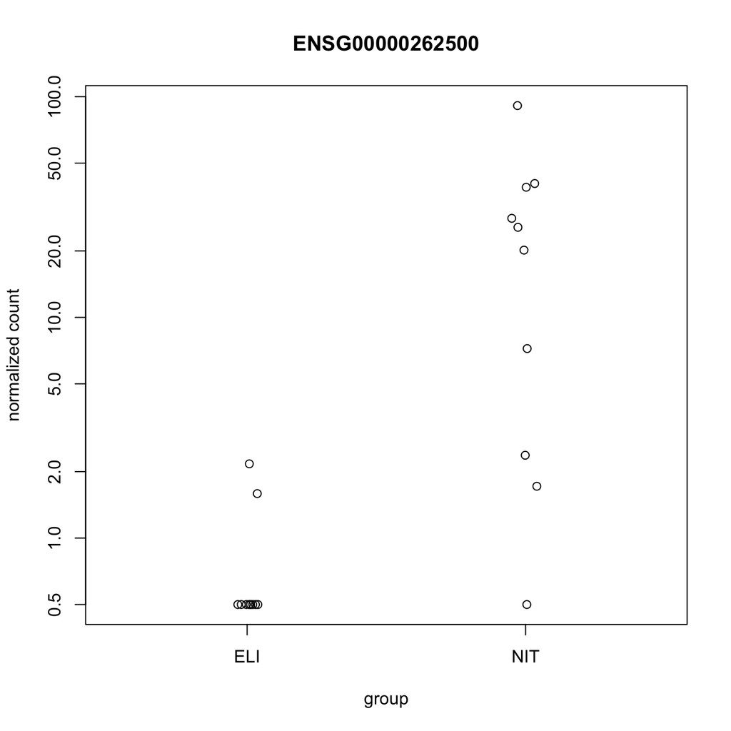

Counts plot para comparación ELI_vs_NIT

En el caso de la comparación `ELI_vs_NIT` se observó que las muestras del grupo *NIT* tienen un número mucho más elevado de conteo que las del grupo *ELI* lo que puede indicar una expresión diferencial entre grupos.

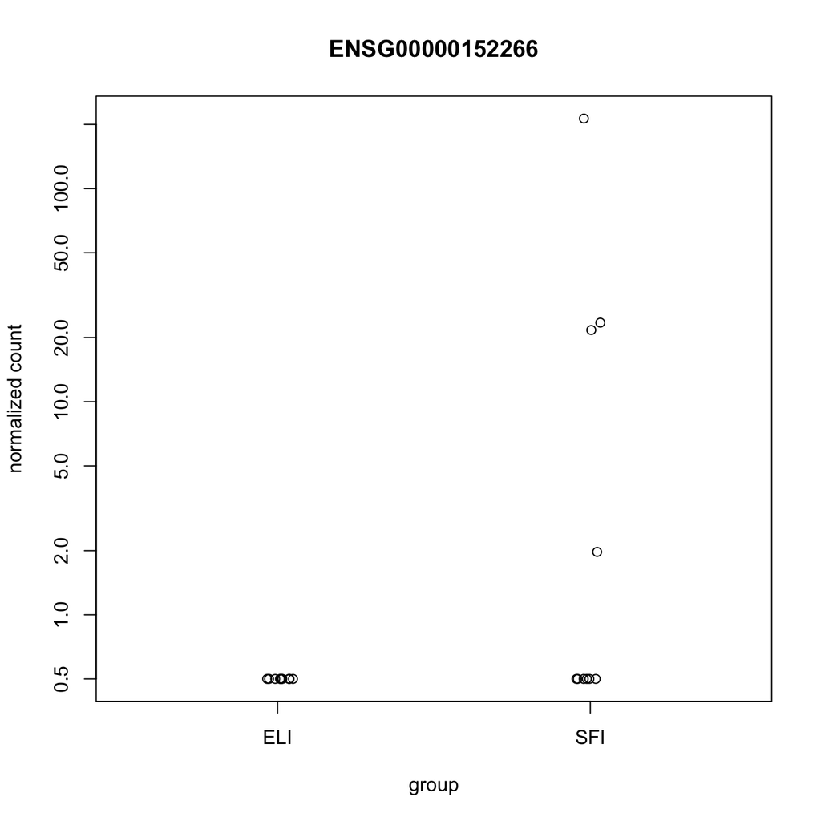

Counts plot para comparación ELI_vs_SFI

En el caso de la comparación `ELI_vs_SFI` se observó que algunas muestras del grupo *SFI* tenían conteos elevados pero que la mayoria de las muestras tenían conteos muy bajos.

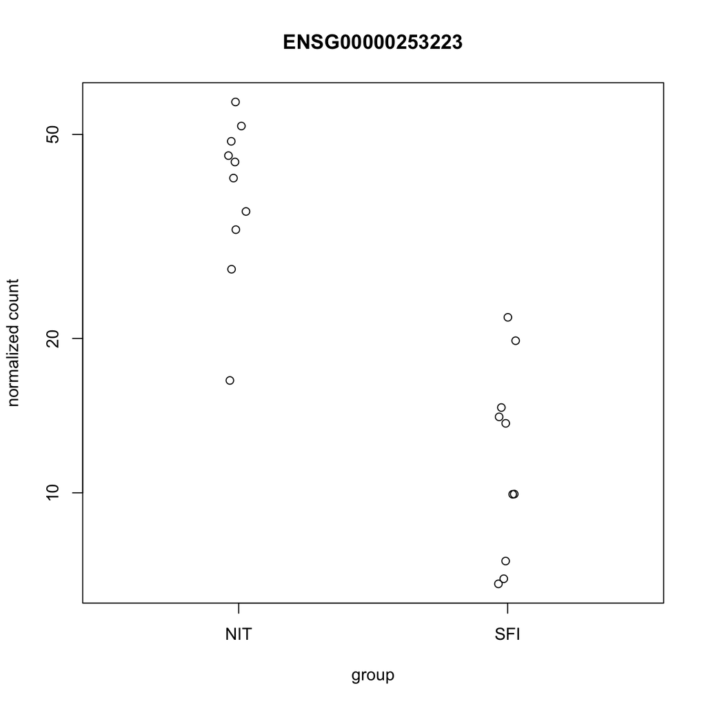

Counts plot para comparación NIT_vs_SFI

Por último, en el caso de la comparación `NIT_vs_SFI` se observó que las muestras del grupo *NIT* tenían un número de conteo más elevado que las muestras del grupo *SFI*.

## MA plot

El gráfico MA (Dudoit 2002) muestra la distribución de los coeficiente estimados en el modelo en todos los genes. En el eje y (M) se representa la resta de los valores logarítmicos mientras que en eje x (A) se representa la media de los coeficientes. En este caso se generan 6 gráficos usando la función `plotMA()` ya que para cada comparación se comparan los valores de los resultados estándar (`res`) con los obtenidos tras la contracción (`resLFC`).

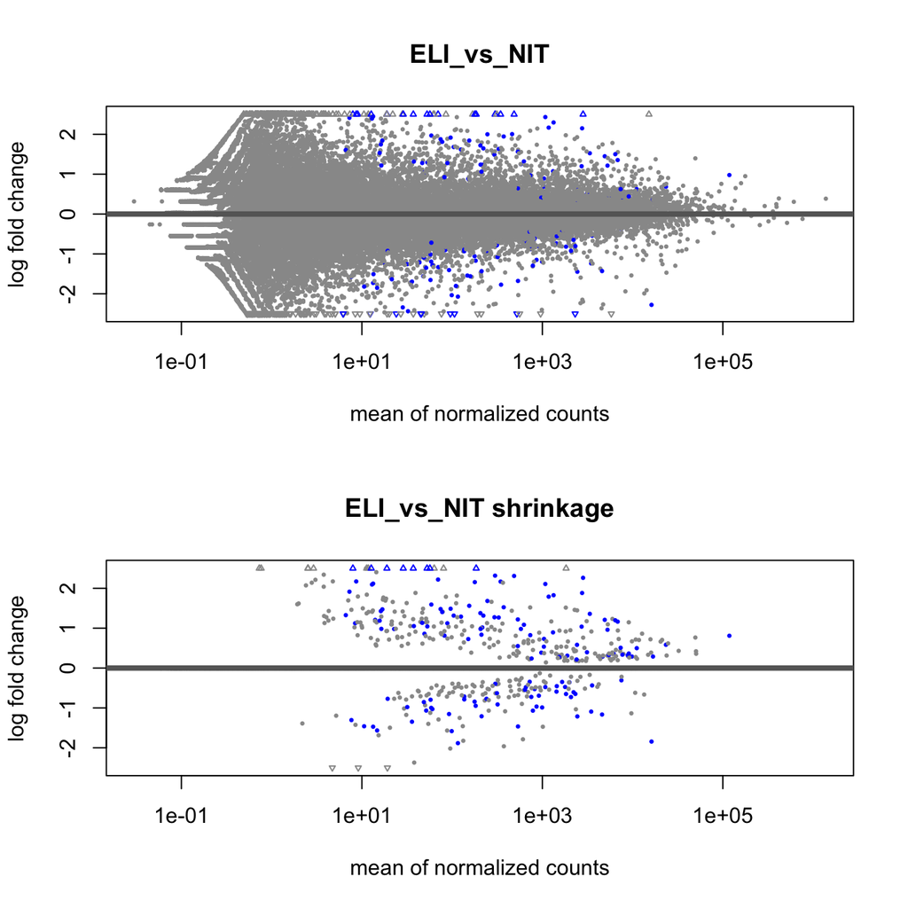

Plot MA para comparación ELI_vs_NIT

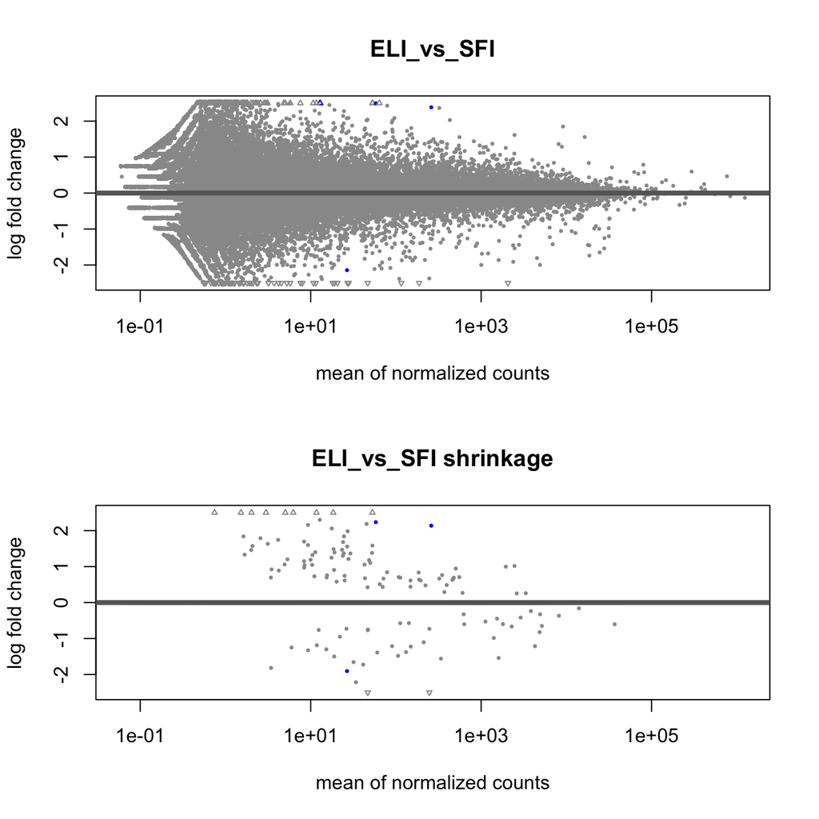

Plot MA para comparación ELI_vs_SFI

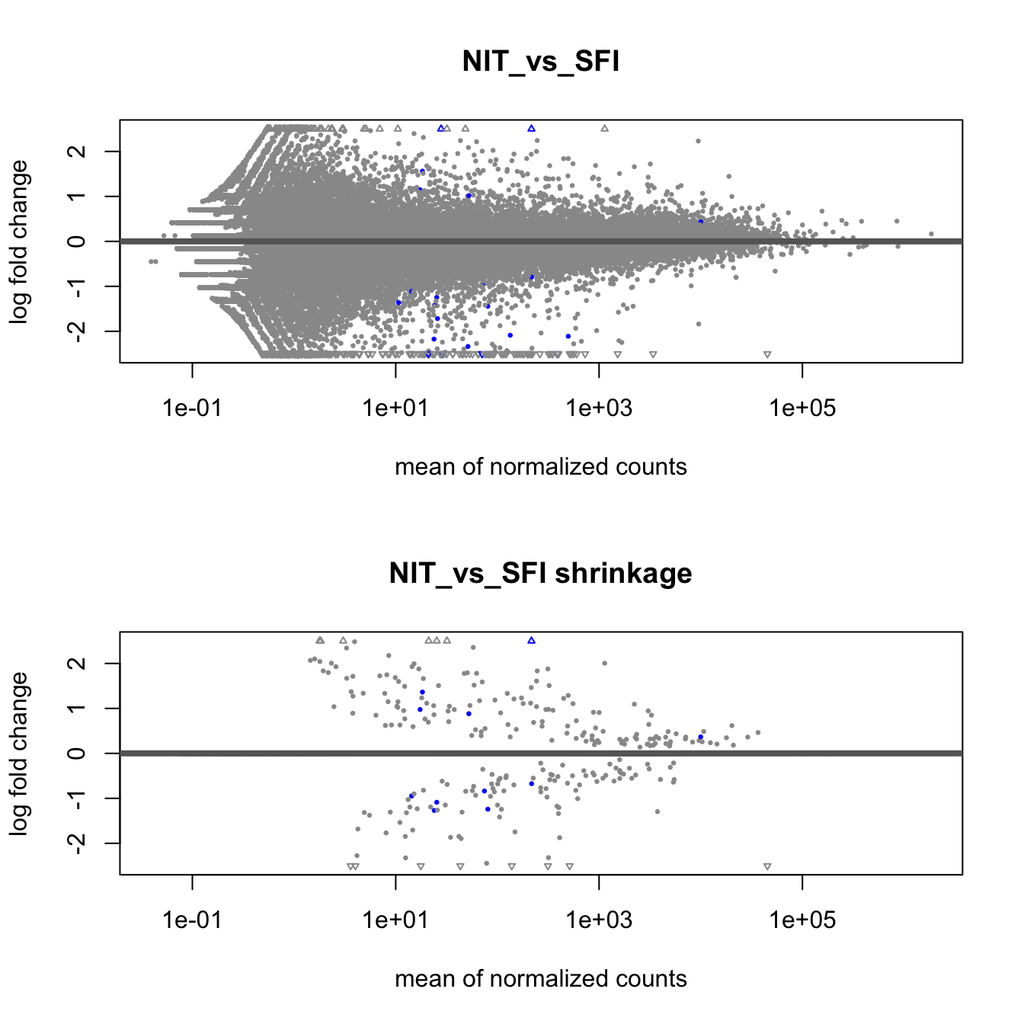

Plot MA para comparación NIT_vs_SFI

En todos los casos se observó que el efecto de la contracción es muy útil para ver los genes con mayor expresión que destacan del ruido.

## Gene clustering

Para evaluar el agrupamiento de la expresión de los genes, se generan heatmaps con agrupamiento para los genes con más variabilidad dentro de las muestras. En este caso se utilizarán los datos normalizados *vst* y se generará un gráfico por comparación.

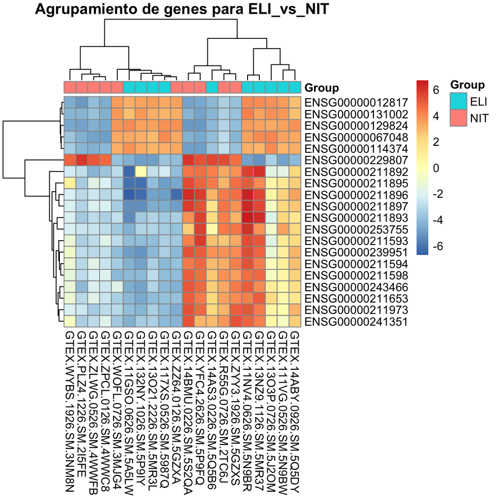

En el gráfico para la comparación `ELI_vs_NIT` se observó bastante correlación entre el patrón de expresión y el grupo para los genes más expresados de la lista mientras que en los genes menos expresados de la lista este comportamiento parece que cambia.

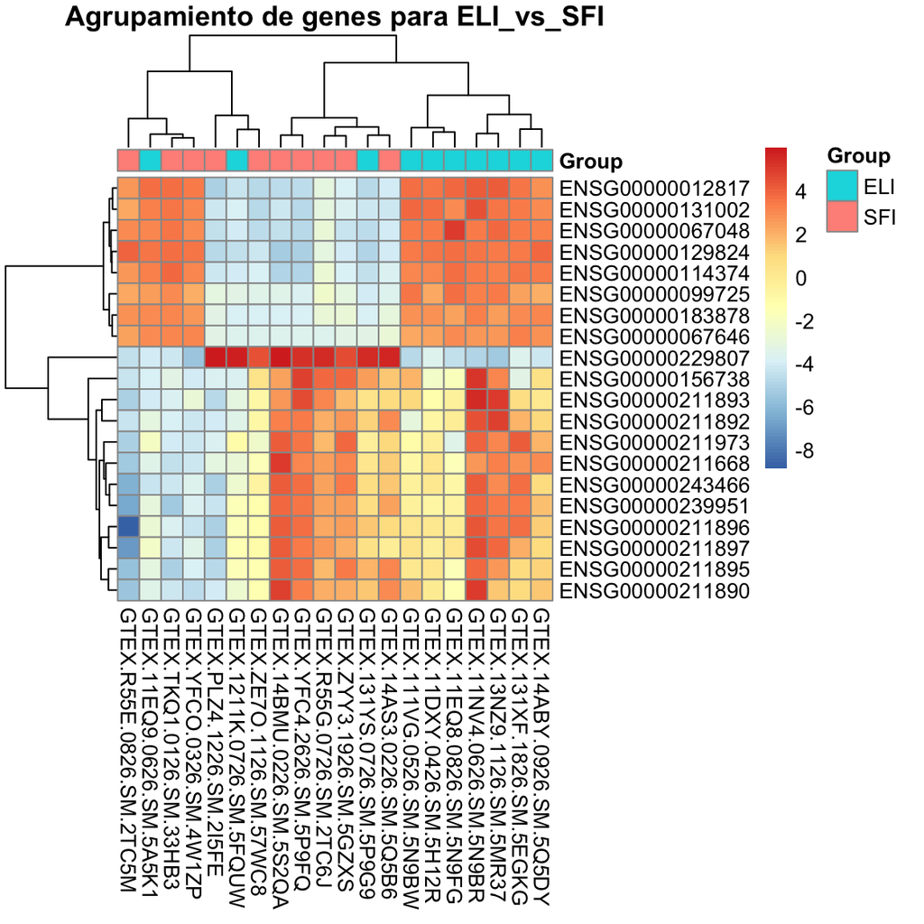

En el gráfico para la comparación `ELI_vs_SFI` se observó una correlación algo menor que en la comparación anterior para los genes más expresados aunque se observó el mismo cambio en los genes menos expresados.

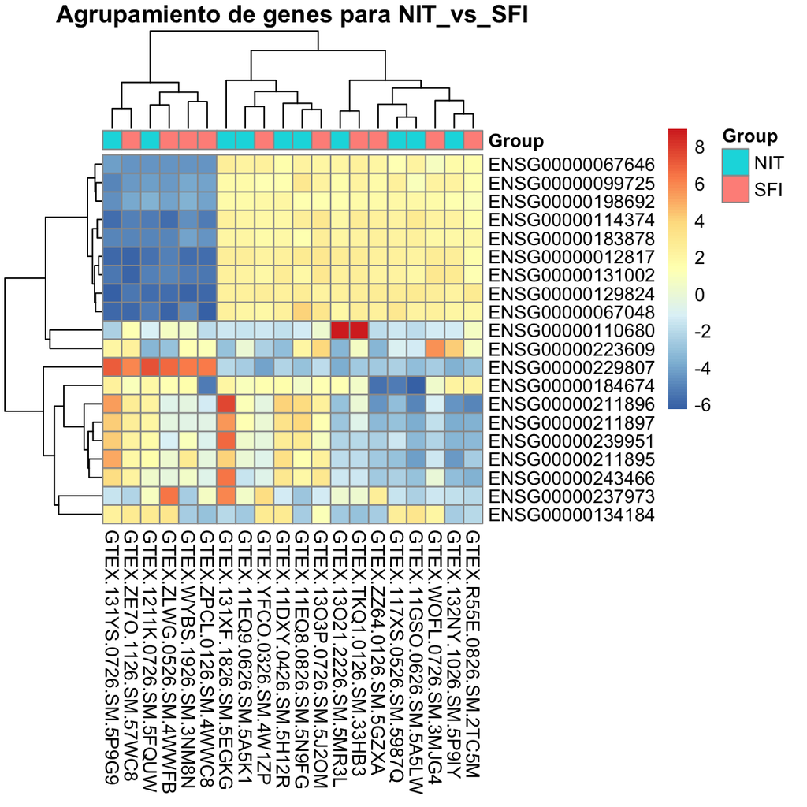

## Anotación

La tabla de resultados obtenida anteriormente sólo contiene información sobre IDs de *Ensembl* pero el nombre de los genes suele ser más informativo. Para añadir esta información se utiliza, por ejemplo, las anotaciones de los paquetes `AnnotationDbi` y `org.Hs.eg.db`. Por supuesto se anotan las tres tablas de resultados obtenidas de las tres comparaciones.

```
log2 fold change (MLE): Group NIT vs ELI
Wald test p-value: Group NIT vs ELI
DataFrame with 6 rows and 8 columns
                  baseMean log2FoldChange     lfcSE      stat      pvalue
                 <numeric>      <numeric> <numeric> <numeric>   <numeric>
ENSG00000262500   12.69085       6.243608 1.0289542   6.06792 1.29580e-09
ENSG00000100417  973.49443       0.409884 0.0684637   5.98688 2.13901e-09
ENSG00000177732 2218.60281      -0.648346 0.1132001  -5.72744 1.01960e-08
ENSG00000160282  115.91896      -2.071988 0.4185460  -4.95044 7.40453e-07
ENSG00000116981    2.53275       4.151607 0.8400603   4.94203 7.73114e-07
ENSG00000099715    6.19176      -3.946984 0.8100160  -4.87272 1.10070e-06
                       padj      symbol      entrez
                  <numeric> <character> <character>
ENSG00000262500 2.54339e-05          NA          NA
ENSG00000100417 2.54339e-05        PMM1        5372
ENSG00000177732 8.08241e-05       SOX12        6666
ENSG00000160282 4.40218e-03        FTCD       10841
ENSG00000116981          NA      NT5C1A       84618
ENSG00000099715 5.23516e-03     PCDH11Y       83259
```

```
log2 fold change (MLE): Group SFI vs ELI
Wald test p-value: Group SFI vs ELI
DataFrame with 6 rows and 8 columns
                 baseMean log2FoldChange     lfcSE      stat      pvalue
                <numeric>      <numeric> <numeric> <numeric>   <numeric>
ENSG00000152266  12.90835       22.20773  2.958250   7.50705 6.04750e-14
ENSG00000230202 259.86155        2.38494  0.515246   4.62873 3.67909e-06
ENSG00000259001  58.15111        2.49447  0.539536   4.62336 3.77577e-06
ENSG00000053108  26.65719       -2.14436  0.476398  -4.50118 6.75768e-06
ENSG00000135346   5.73578       -3.71040  0.861397  -4.30743 1.65166e-05
ENSG00000172179 115.74380       -4.70482  1.096994  -4.28883 1.79615e-05
                       padj      symbol      entrez
                  <numeric> <character> <character>
ENSG00000152266 2.51648e-09         PTH        5741
ENSG00000230202 5.23725e-02          NA          NA
ENSG00000259001 5.23725e-02          NA          NA
ENSG00000053108 7.03001e-02       FSTL4       23105
ENSG00000135346 1.11718e-01         CGA        1081
ENSG00000172179 1.11718e-01         PRL        5617
```

```
log2 fold change (MLE): Group SFI vs NIT
Wald test p-value: Group SFI vs NIT
DataFrame with 6 rows and 8 columns
                 baseMean log2FoldChange     lfcSE      stat      pvalue
                <numeric>      <numeric> <numeric> <numeric>   <numeric>
ENSG00000253223   25.7825      -1.716661  0.277073  -6.19571 5.80243e-10
ENSG00000237541  216.3409       3.254140  0.614638   5.29440 1.19406e-07
ENSG00000211950  386.9772      -6.419589  1.325903  -4.84167 1.28751e-06
ENSG00000254681  497.7346      -2.110326  0.448080  -4.70971 2.48068e-06
ENSG00000160282  133.8091      -2.087634  0.452661  -4.61192 3.98973e-06
ENSG00000251429   74.5641      -0.935283  0.202975  -4.60787 4.06805e-06
                       padj              symbol      entrez
                  <numeric>         <character> <character>
ENSG00000253223 1.41463e-05                  NA          NA
ENSG00000237541 1.45556e-03            HLA-DQA1        3117
ENSG00000211950 1.04631e-02                  NA          NA
ENSG00000254681 1.51197e-02 PKD1P5-LOC105376752   110006322
ENSG00000160282 1.65299e-02                FTCD       10841
ENSG00000251429 1.65299e-02                  NA          NA
```

## Resumen de resultados

Con esto se podría dar por finalizado el estudio sobre los datos de RNA-seq pero es convieniente guardar los resultados generados durante el análisis. En este caso se guardarán los objetos `counts`, `targets`, `res` y `res_ord` para cada una de las comparaciones.

Estos ficheros de resultados se encuentran resumidos en el siguiente listado.

| ListadoFicheros |
| --- |
| counts_ELI_vs_NIT.csv |
| counts_ELI_vs_SFI.csv |
| counts_NIT_vs_SFI.csv |
| res_ELI_vs_NIT.csv |
| res_ELI_vs_SFI.csv |
| res_NIT_vs_SFI.csv |
| res_ord_ELI_vs_NIT.csv |
| res_ord_ELI_vs_SFI.csv |
| res_ord_NIT_vs_SFI.csv |
| targets_ELI_vs_NIT.csv |
| targets_ELI_vs_SFI.csv |
| targets_NIT_vs_SFI.csv |

# CONCLUSIÓN

El principal resultado del análisis ha sido que no hay una relación clara entre el tipo de tejido y la expresión génica. Hay pequeños indicios que no descartan esta relación, sobre todo en el caso del grupo *NIT*, pero posiblemente el pequeño tamaño de la muestra aleatoria sobre la que se ha realizado el análisis ha imposibilitado obtener unas conclusiones más claras.

# APÉNDICE

En este apartado se muestra en código utilizado a lo largo de todo el informe.

```r
> #1. Preparación del entorno
>
> setwd("~/Desktop/Master UOC/Semestre 3/Asignaturas/
+       157-Analisis de datos omicos/PEC2/ADO_PEC2")
> workingDir <- getwd()
> dir.create("data")
> dir.create("results")
> dataDir <- file.path(workingDir, "data/")
> resultsDir <- file.path(workingDir, "results/")
>
> #2. Lectura de datos
>
> counts <- read.csv("./data/counts.csv", sep = ";", header = T)
> targets <- read.csv("./data/targets.csv", header = T)
>
> head(counts[,1:3],3)
> head(targets, 3)
>
> #3. Modificación de los objetos `counts` y `targets`
>
> names(counts)[1] <- "Ensembl"
> counts$Ensembl <- gsub("\\..*", "", counts$Ensembl, fixed = FALSE)
>
> head(counts$Ensembl)
>
> targets$Sample_Name <- gsub("-", ".", x = as.character(targets$Sample_Name))
>
> head(targets, 3)
>
> #4. Selección aleatoria de muestras
>
> targets_NIT <- targets[targets$Group=="NIT",]
> targets_ELI <- targets[targets$Group=="ELI",]
> targets_SFI <- targets[targets$Group=="SFI",]
>
> set.seed(2020)
>
> targets_ELI_rndm <- targets_ELI[sample(nrow(targets_ELI), 10),]
> targets_SFI_rndm <- targets_SFI[sample(nrow(targets_SFI), 10),]
> targets_NIT_rndm <- targets_NIT[sample(nrow(targets_NIT), 10),]
>
> targets_ELI_rndm
> targets_SFI_rndm
> targets_NIT_rndm
>
> targets_ELI_vs_NIT <- do.call(what = rbind,
+                               args =list(targets_ELI_rndm, targets_NIT_rndm))
>
> targets_ELI_vs_SFI <- do.call(what = rbind,
+                               args =list(targets_ELI_rndm, targets_SFI_rndm))
>
> targets_NIT_vs_SFI <- do.call(what = rbind,
+                               args =list(targets_NIT_rndm, targets_SFI_rndm))
>
> #5. Modificación del archivo `counts` según el muestreo
>
> counts_red_ELI_vs_NIT <- cbind(counts$Ensembl,
+                                counts[colnames(counts) %in%
+                                         targets_ELI_vs_NIT$Sample_Name])
> counts_ELI_vs_NIT <- counts_red_ELI_vs_NIT[,-1]
> rownames(counts_ELI_vs_NIT) <- counts_red_ELI_vs_NIT[,1]
> all(rownames(targets_ELI_vs_NIT$Sample_Name) == colnames(counts_ELI_vs_NIT))
>
> counts_red_ELI_vs_SFI <- cbind(counts$Ensembl,
+                                counts[colnames(counts) %in%
+                                         targets_ELI_vs_SFI$Sample_Name])
> counts_ELI_vs_SFI <- counts_red_ELI_vs_SFI[,-1]
> rownames(counts_ELI_vs_SFI) <- counts_red_ELI_vs_SFI[,1]
> all(rownames(targets_ELI_vs_SFI$Sample_Name) == colnames(counts_ELI_vs_SFI))
>
> counts_red_NIT_vs_SFI <- cbind(counts$Ensembl,
+                                counts[colnames(counts) %in%
+                                         targets_NIT_vs_SFI$Sample_Name])
> counts_NIT_vs_SFI <- counts_red_NIT_vs_SFI[,-1]
> rownames(counts_NIT_vs_SFI) <- counts_red_NIT_vs_SFI[,1]
> all(rownames(targets_NIT_vs_SFI$Sample_Name) == colnames(counts_NIT_vs_SFI))
>
> head(counts_ELI_vs_NIT[,1:3], 3)
> head(counts_ELI_vs_SFI[,1:3], 3)
> head(counts_NIT_vs_SFI[,1:3], 3)
>
>
> #6. Construcción de los objetos `DESeqDataSet` usando de datos sin normalizar
>
> library("DESeq2")
>
> dds_ELI_vs_NIT <- DESeqDataSetFromMatrix(countData = counts_ELI_vs_NIT,
+                                          colData = targets_ELI_vs_NIT,
+                                          design = ~ Group)
> dds_ELI_vs_SFI <- DESeqDataSetFromMatrix(countData = counts_ELI_vs_SFI,
+                                          colData = targets_ELI_vs_SFI,
+                                          design = ~ Group)
> dds_NIT_vs_SFI <- DESeqDataSetFromMatrix(countData = counts_NIT_vs_SFI,
+                                          colData = targets_NIT_vs_SFI,
+                                          design = ~ Group)
>
> dds_ELI_vs_NIT
> dds_ELI_vs_SFI
> dds_NIT_vs_SFI
>
> #7. Filtraje de los datos
>
> nrow(dds_ELI_vs_NIT)
> keep_ELI_vs_NIT <- rowSums(counts(dds_ELI_vs_NIT)) > 1
> dds_ELI_vs_NIT <- dds_ELI_vs_NIT[keep_ELI_vs_NIT,]
> nrow(dds_ELI_vs_NIT)
>
> nrow(dds_ELI_vs_SFI)
> keep_ELI_vs_SFI <- rowSums(counts(dds_ELI_vs_SFI)) > 1
> dds_ELI_vs_SFI <- dds_ELI_vs_SFI[keep_ELI_vs_SFI,]
> nrow(dds_ELI_vs_SFI)
>
> nrow(dds_NIT_vs_SFI)
> keep_NIT_vs_SFI <- rowSums(counts(dds_NIT_vs_SFI)) > 1
> dds_NIT_vs_SFI <- dds_NIT_vs_SFI[keep_NIT_vs_SFI,]
> nrow(dds_NIT_vs_SFI)
>
> #8. Estabilización de la varianza
>
> vsd_ELI_vs_NIT <- vst(dds_ELI_vs_NIT, blind = F)
> vsd_ELI_vs_SFI <- vst(dds_ELI_vs_SFI, blind = F)
> vsd_NIT_vs_SFI <- vst(dds_NIT_vs_SFI, blind = F)
>
> rld_ELI_vs_NIT <- rlog(dds_ELI_vs_NIT, blind = F)
> rld_ELI_vs_SFI <- rlog(dds_ELI_vs_SFI, blind = F)
> rld_NIT_vs_SFI <- rlog(dds_NIT_vs_SFI, blind = F)
>
> #9. Distancia entre las muestras
>
> sampleDists_ELI_vs_NIT <- dist(t(assay(vsd_ELI_vs_NIT)))
> sampleDists_ELI_vs_SFI <- dist(t(assay(vsd_ELI_vs_SFI)))
> sampleDists_NIT_vs_SFI <- dist(t(assay(vsd_NIT_vs_SFI)))
>
> library("pheatmap")
> library("RColorBrewer")
>
> sampleDistMatrix_ELI_vs_NIT <- as.matrix(sampleDists_ELI_vs_NIT)
> rownames(sampleDistMatrix_ELI_vs_NIT) <- vsd_ELI_vs_NIT$Group
> colnames(sampleDistMatrix_ELI_vs_NIT) <- NULL
> colors <- colorRampPalette( rev(brewer.pal(9, "Blues")) )(255)
> pheatmap(sampleDistMatrix_ELI_vs_NIT,
+          clustering_distance_rows = sampleDists_ELI_vs_NIT,
+          clustering_distance_cols = sampleDists_ELI_vs_NIT,
+          col = colors)
>
> sampleDistMatrix_ELI_vs_SFI <- as.matrix(sampleDists_ELI_vs_SFI)
> rownames(sampleDistMatrix_ELI_vs_SFI) <- vsd_ELI_vs_SFI$Group
> colnames(sampleDistMatrix_ELI_vs_SFI) <- NULL
> colors <- colorRampPalette( rev(brewer.pal(9, "Blues")) )(255)
> pheatmap(sampleDistMatrix_ELI_vs_SFI,
+          clustering_distance_rows = sampleDists_ELI_vs_SFI,
+          clustering_distance_cols = sampleDists_ELI_vs_SFI,
+          col = colors)
>
> sampleDistMatrix_NIT_vs_SFI <- as.matrix(sampleDists_NIT_vs_SFI)
> rownames(sampleDistMatrix_NIT_vs_SFI) <- vsd_NIT_vs_SFI$Group
> colnames(sampleDistMatrix_NIT_vs_SFI) <- NULL
> colors <- colorRampPalette( rev(brewer.pal(9, "Blues")) )(255)
> pheatmap(sampleDistMatrix_NIT_vs_SFI,
+          clustering_distance_rows = sampleDists_NIT_vs_SFI,
+          clustering_distance_cols = sampleDists_NIT_vs_SFI,
+          col = colors)
>
> #10. Análisis de componentes principales (PCA)
>
> plotPCA(vsd_ELI_vs_NIT, intgroup="Group")
>
> plotPCA(vsd_ELI_vs_SFI, intgroup="Group")
>
> plotPCA(vsd_NIT_vs_SFI, intgroup="Group")
>
> #11. Análisis de expresión diferencial
>
> dds_ELI_vs_NIT <- DESeq(dds_ELI_vs_NIT)
> res_ELI_vs_NIT <- results(dds_ELI_vs_NIT)
>
> dds_ELI_vs_SFI <- DESeq(dds_ELI_vs_SFI)
> res_ELI_vs_SFI <- results(dds_ELI_vs_SFI)
>
> dds_NIT_vs_SFI <- DESeq(dds_NIT_vs_SFI)
> res_NIT_vs_SFI <- results(dds_NIT_vs_SFI)
>
> dds_ELI_vs_NIT
> head(res_ELI_vs_NIT, 5)
>
> dds_ELI_vs_SFI
> head(res_ELI_vs_SFI,5)
>
> dds_NIT_vs_SFI
> head(res_NIT_vs_SFI,5)
>
> resultsNames(dds_ELI_vs_NIT)
> resultsNames(dds_ELI_vs_SFI)
> resultsNames(dds_NIT_vs_SFI)
>
> #12. Contracción del cambio de log fold
>
> library("apeglm")
>
> resLFC_ELI_vs_NIT <- lfcShrink(dds_ELI_vs_NIT,
+                                coef="Group_NIT_vs_ELI", type = "apeglm")
> resLFC_ELI_vs_SFI <- lfcShrink(dds_ELI_vs_SFI,
+                                coef="Group_SFI_vs_ELI", type = "apeglm")
> resLFC_NIT_vs_SFI <- lfcShrink(dds_NIT_vs_SFI,
+                                coef="Group_SFI_vs_NIT", type = "apeglm")
>
> head(resLFC_ELI_vs_NIT, 5)
> head(resLFC_ELI_vs_SFI, 5)
> head(resLFC_NIT_vs_SFI, 5)
>
> #13. Counts plot
>
> plotCounts(dds_ELI_vs_NIT,
+            gene=which.min(res_ELI_vs_NIT$padj), intgroup="Group")
>
> plotCounts(dds_ELI_vs_SFI,
+            gene=which.min(res_ELI_vs_SFI$padj), intgroup="Group")
>
> plotCounts(dds_NIT_vs_SFI,
+            gene=which.min(res_NIT_vs_SFI$padj), intgroup="Group")
>
> #14. MA plot
>
> par(mfrow=c(2,1))
>
> plotMA(res_ELI_vs_NIT, ylim=c(-2.5,2.5), main="ELI_vs_NIT")
> plotMA(resLFC_ELI_vs_NIT, ylim=c(-2.5,2.5), main="ELI_vs_NIT shrinkage")
>
> par(mfrow=c(2,1))
>
> plotMA(res_ELI_vs_SFI, ylim=c(-2.5,2.5), main="ELI_vs_SFI")
> plotMA(resLFC_ELI_vs_SFI, ylim=c(-2.5,2.5), main="ELI_vs_SFI shrinkage")
>
> par(mfrow=c(2,1))
>
> plotMA(res_NIT_vs_SFI, ylim=c(-2.5,2.5), main="NIT_vs_SFI")
> plotMA(resLFC_NIT_vs_SFI, ylim=c(-2.5,2.5), main="NIT_vs_SFI shrinkage")
>
> #15. Gene clustering
>
> library("genefilter")
>
> topVarGenes_ELI_vs_NIT <- head(order(rowVars(assay(vsd_ELI_vs_NIT)),
+                                      decreasing = TRUE), 20)
> mat_ELI_vs_NIT  <- assay(vsd_ELI_vs_NIT)[topVarGenes_ELI_vs_NIT, ]
> mat_ELI_vs_NIT  <- mat_ELI_vs_NIT - rowMeans(mat_ELI_vs_NIT)
> Group <- colData(vsd_ELI_vs_NIT)[,"Group"]
> anno_ELI_vs_NIT <- as.data.frame(Group)
> rownames(anno_ELI_vs_NIT) <- colnames(mat_ELI_vs_NIT)
> pheatmap(mat_ELI_vs_NIT, annotation_col = anno_ELI_vs_NIT,
+          main = "Agrupamiento de genes para ELI_vs_NIT")
>
> topVarGenes_ELI_vs_SFI <- head(order(rowVars(assay(vsd_ELI_vs_SFI)),
+                                      decreasing = TRUE), 20)
> mat_ELI_vs_SFI  <- assay(vsd_ELI_vs_SFI)[topVarGenes_ELI_vs_SFI, ]
> mat_ELI_vs_SFI  <- mat_ELI_vs_SFI - rowMeans(mat_ELI_vs_SFI)
> Group <- colData(vsd_ELI_vs_SFI)[,"Group"]
> anno_ELI_vs_SFI <- as.data.frame(Group)
> rownames(anno_ELI_vs_SFI) <- colnames(mat_ELI_vs_SFI)
> pheatmap(mat_ELI_vs_SFI, annotation_col = anno_ELI_vs_SFI,
+          main = "Agrupamiento de genes para ELI_vs_SFI")
>
> topVarGenes_NIT_vs_SFI <- head(order(rowVars(assay(vsd_NIT_vs_SFI)),
+                                      decreasing = TRUE), 20)
> mat_NIT_vs_SFI  <- assay(vsd_NIT_vs_SFI)[topVarGenes_NIT_vs_SFI, ]
> mat_NIT_vs_SFI  <- mat_NIT_vs_SFI - rowMeans(mat_NIT_vs_SFI)
> Group <- colData(vsd_NIT_vs_SFI)[,"Group"]
> anno_NIT_vs_SFI <- as.data.frame(Group)
> rownames(anno_NIT_vs_SFI) <- colnames(mat_NIT_vs_SFI)
> pheatmap(mat_NIT_vs_SFI, annotation_col = anno_NIT_vs_SFI,
+          main = "Agrupamiento de genes para NIT_vs_SFI")
>
> #16. Anotación
>
> library("AnnotationDbi")
> library("org.Hs.eg.db")
>
> res_ELI_vs_NIT$symbol <- mapIds(org.Hs.eg.db,
+                                 keys = row.names(res_ELI_vs_NIT),
+                                 column = "SYMBOL",
+                                 keytype = "ENSEMBL",
+                                 multiVals = "first")
> res_ELI_vs_NIT$entrez <- mapIds(org.Hs.eg.db,
+                                 keys = row.names(res_ELI_vs_NIT),
+                                 column = "ENTREZID",
+                                 keytype = "ENSEMBL",
+                                 multiVals = "first")
> res_ord_ELI_vs_NIT <- res_ELI_vs_NIT[order(res_ELI_vs_NIT$pvalue),]
> head(res_ord_ELI_vs_NIT)
>
> res_ELI_vs_SFI$symbol <- mapIds(org.Hs.eg.db,
+                                 keys = row.names(res_ELI_vs_SFI),
+                                 column = "SYMBOL",
+                                 keytype = "ENSEMBL",
+                                 multiVals = "first")
> res_ELI_vs_SFI$entrez <- mapIds(org.Hs.eg.db,
+                                 keys = row.names(res_ELI_vs_SFI),
+                                 column = "ENTREZID",
+                                 keytype = "ENSEMBL",
+                                 multiVals = "first")
> res_ord_ELI_vs_SFI <- res_ELI_vs_SFI[order(res_ELI_vs_SFI$pvalue),]
> head(res_ord_ELI_vs_SFI)
>
> res_NIT_vs_SFI$symbol <- mapIds(org.Hs.eg.db,
+                                 keys = row.names(res_NIT_vs_SFI),
+                                 column = "SYMBOL",
+                                 keytype = "ENSEMBL",
+                                 multiVals = "first")
> res_NIT_vs_SFI$entrez <- mapIds(org.Hs.eg.db,
+                                 keys = row.names(res_NIT_vs_SFI),
+                                 column = "ENTREZID",
+                                 keytype = "ENSEMBL",
+                                 multiVals = "first")
> res_ord_NIT_vs_SFI <- res_NIT_vs_SFI[order(res_NIT_vs_SFI$pvalue),]
> head(res_ord_NIT_vs_SFI)
>
> #17. Resumen de resultados
>
> write.csv(counts_ELI_vs_NIT, file = "./results/counts_ELI_vs_NIT.csv")
```

```r
> write.csv(counts_ELI_vs_SFI, file = "./results/counts_ELI_vs_SFI.csv")
> write.csv(counts_NIT_vs_SFI, file = "./results/counts_NIT_vs_SFI.csv")
>
> write.csv(targets_ELI_vs_NIT, file = "./results/targets_ELI_vs_NIT.csv")
> write.csv(targets_ELI_vs_SFI, file = "./results/targets_ELI_vs_SFI.csv")
> write.csv(targets_NIT_vs_SFI, file = "./results/targets_NIT_vs_SFI.csv")
>
> write.csv(as.data.frame(res_ELI_vs_NIT), file = "./results/res_ELI_vs_NIT.csv")
> write.csv(as.data.frame(res_ELI_vs_SFI), file = "./results/res_ELI_vs_SFI.csv")
> write.csv(as.data.frame(res_NIT_vs_SFI), file = "./results/res_NIT_vs_SFI.csv")
>
> write.csv(as.data.frame(res_ord_ELI_vs_NIT), file = "./results/res_ord_ELI_vs_NIT.csv")
> write.csv(as.data.frame(res_ord_ELI_vs_SFI), file = "./results/res_ord_ELI_vs_SFI.csv")
> write.csv(as.data.frame(res_ord_NIT_vs_SFI), file = "./results/res_ord_NIT_vs_SFI.csv")
>
> listOfFiles <- dir("./results/")
> knitr::kable(
+   listOfFiles, booktabs = TRUE,
+   col.names="ListadoFicheros"
+ )
```

# REFERENCIAS

Anders, W., S.; Huber. 2010. “Differential Expression Analysis for Sequence Count Data.” *Genome Biology* 11. doi:10.1186/gb-2010-11-10-r106.

Dudoit, Y. W.; Callow, S.; Yang. 2002. “Statistical Methods for Identifying Differentially Expressed Genes in Replicated cDNA Microarray Experiments.” *Statistica Sinica* 12: 111–39.

Love, W.; Anders, M. I.; Huber. 2014. “Moderated Estimation of Fold Change and Dispersion for Rna-Seq Data with Deseq2.” *Genome Biology* 15. doi:10.1186/s13059-014-0550-8.

Zhu, J. G.; Love, A.; Ibrahim. 2018. “Heavy-Tailed Prior Distributions for Sequence Count Data: Removing the Noise and Preserving Large Differences.” *Bioinformatics* 35 (12): 2084–92. doi:10.1093/bioinformatics/bty895.

[^1]: https://www.gtexportal.org/home/
[^2]: https://github.com/adurana/ADO_PEC2
[^3]: https://github.com/ASPteaching/Omics_data_analysis-Case_study_2-RNA-seq
[^4]: http://master.bioconductor.org/packages/release/workflows/vignettes/rnaseqGene/inst/doc/rnaseqGene.html#aligning-reads-to-a-reference-genome
[^5]: http://bioconductor.org/packages/release/bioc/vignettes/DESeq2/inst/doc/DESeq2.html#pre-filtering